# Romano-British Pottery Data Analysis

## Cyril Gorlla

### University of California, San Diego

## Introduction

We wish to investigate whether there is a significant difference among 5 group means for 9 chemicals in the Romano-British Pottery dataset.

1. Al2O3: aluminium trioxide
2. Fe2O3: iron trioxide
3. MgO: magnesium oxide
4. CaO: calcium oxide
5. Na2O: natrium oxide
6. K2O: kalium oxide
7. TiO2: titanium oxide
8. MnO: mangan oxide
9. BaO: barium oxide

The dataset contains measurements on 48 pottery shards that were collected from five sites in the British Isles.

1. Gloucester
2. Llanedeyrn
3. Caldicot
4. Islands Thorns
5. Ashley Rails

## Body

We will load in the data.

```r
RBPottery <- read.csv("data.csv")
```

*Source*: [Github](https://github.com/tuckermcelroy/ma189/blob/main/Data/RBPottery.csv)

Baxter, M. J. 2003. *Statistics in Archaeology*. Arnold, London

Tubb, A., A. J. Parker, and G. Nickless. 1980. The Analysis of Romano-British Pottery by Atomic Absorption Spectrophotometry. *Archaeometry* 22: 153-71.

```r
pot_gl <- RBPottery[RBPottery$Kiln==1,]
pot_llan <- RBPottery[RBPottery$Kiln==2,]
pot_cald <- RBPottery[RBPottery$Kiln==3,]
pot_is <- RBPottery[RBPottery$Kiln==4,]
pot_ar <- RBPottery[RBPottery$Kiln==5,]
```

```r
colMeans(pot_ar[-c(1:3)])
```

```
##   Al2O3   Fe2O3     MgO     CaO    Na2O     K2O    TiO2     MnO     BaO
## 17.3200  1.5120  0.6060  0.0520  0.0480  1.9660  0.9940  0.0042  0.0156
```

```r
colMeans(pot_cald[-c(1:3)])
```

```
##   Al2O3   Fe2O3     MgO     CaO    Na2O     K2O    TiO2     MnO     BaO
## 11.7000  5.4150  3.8550  0.2950  0.0500  4.5750  0.5750  0.0975  0.0140
```

```r
colMeans(pot_gl[-c(1:3)])
```

```
##       Al2O3       Fe2O3         MgO         CaO        Na2O         K2O
## 16.94090909  7.43090909  1.83636364  0.94227273  0.34818182  3.10545455
##        TiO2         MnO         BaO
##  0.89636364  0.07172727  0.01713636
```

```r
colMeans(pot_is[-c(1:3)])
```

```
##   Al2O3   Fe2O3     MgO     CaO    Na2O     K2O    TiO2     MnO     BaO
## 18.1800  1.7120  0.6740  0.0260  0.0540  2.0760  1.0460  0.0022  0.0164
```

```r
colMeans(pot_llan[-c(1:3)])
```

```
##      Al2O3      Fe2O3        MgO        CaO       Na2O        K2O       TiO2
## 12.5642857  6.3721429  4.8264286  0.2021429  0.2507143  3.9278571  0.7064286
##        MnO        BaO
##  0.1445000  0.0170000
```

It’s ill-advised to determine whether or not there is a difference in means among these groups simply by looking at the data. Further analysis is required.

### Hypotheses

Null Hypothesis

There is no difference among the group means for the 9 chemicals.

Alternative Hypothesis

There is a difference among the group means for the 9 chemicals (at least two groups are different in means).

$H_0: \underline{\mu}^{(1)} = \underline{\mu}^{(2)} =\ldots = \underline{\mu}^{(g)}\quad \mbox{versus} \quad H_a: \mu_j^{(k)} \neq\mu_{j}^{(h)}$

We will test the equivalence of mean vectors among five populations, for multiple variables. Since we are looking at more than two populations, we use ANOVA. Specifically, since we are investigating multiple variables among these populations, we use the multivariate case. We can use MANOVA (multivariate analysis of variance) to investigate our hypothesis. We will use $\alpha = 0.05$.

### Assumptions

1. The data from group $k$ has common mean vector $\underline{\mu}^{(k)}$, i.e., ${\mathbb E} [ x_{ij}^{(k)} ] = \underline{\mu}_j^{(k)}.$ (The $m$ components of the vector correspond to the $m$ variables.)

This assumption may be violated if pottery collected from the same site had inconsistencies, but should otherwise hold.

2. Homoskedasticity: The data from all groups have common covariance matrix ${\mathbf \Sigma}$, i.e., ${\mathbf \Sigma} = \mbox{Cov} [ \underline{x}_i^{(k)}, \underline{x}_i^{(k)}]$ for any record $i$, and the matrix does not depend on $k$ (the group index).

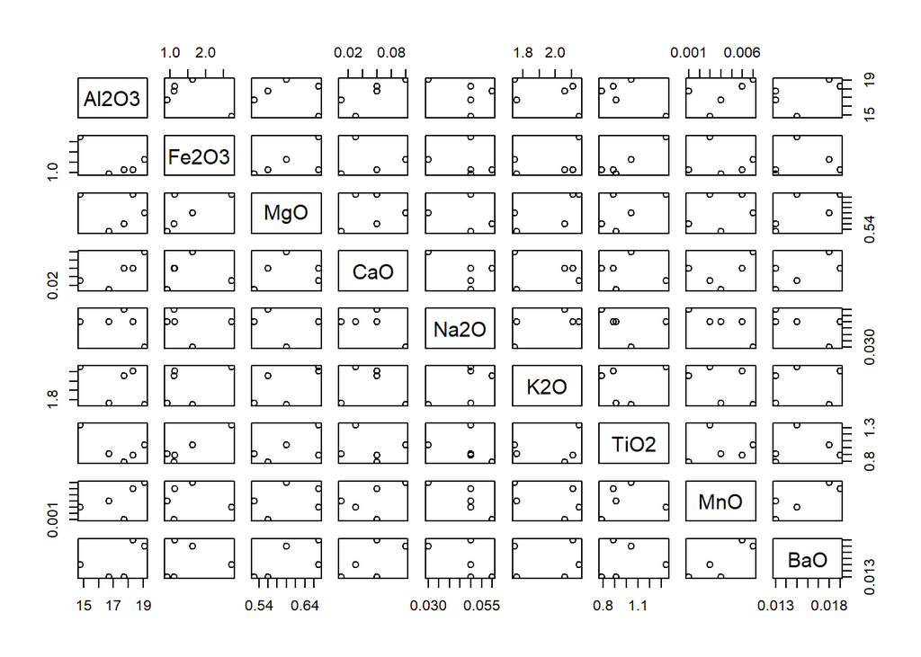

```r
pairs(pot_ar[-c(1:3)])
```

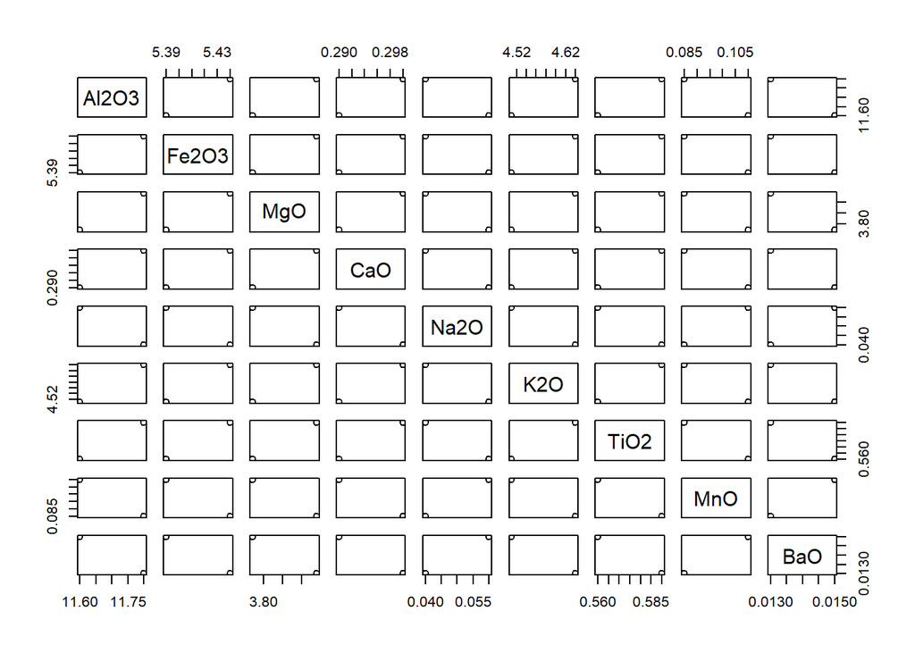

```r
pairs(pot_cald[-c(1:3)])
```

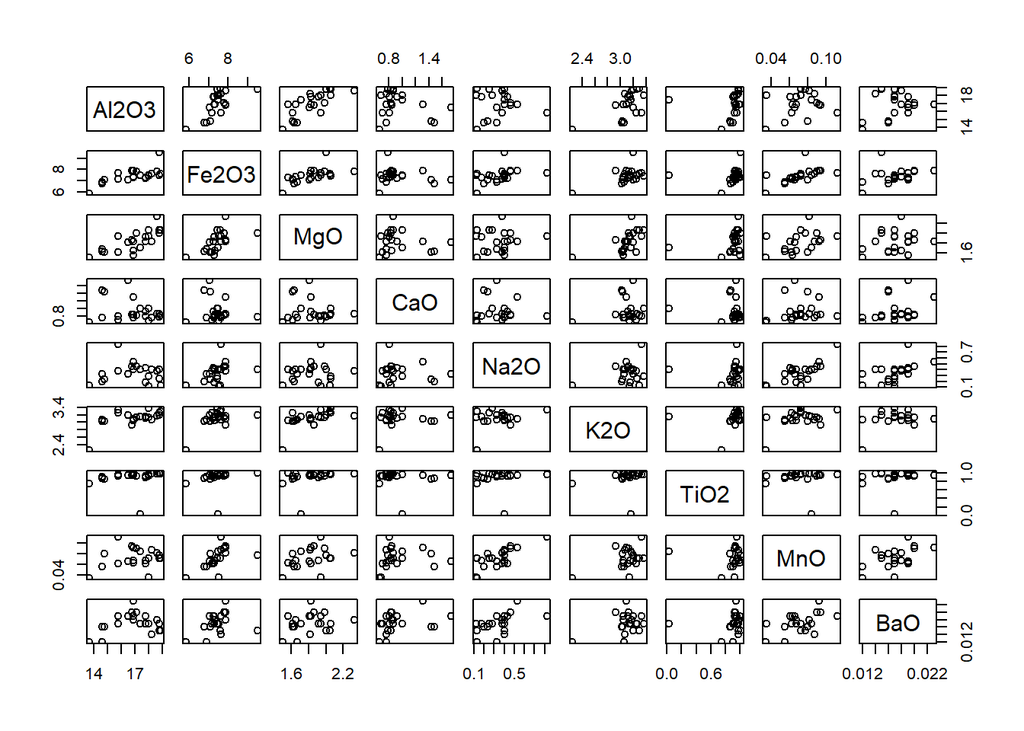

```r
pairs(pot_gl[-c(1:3)])
```

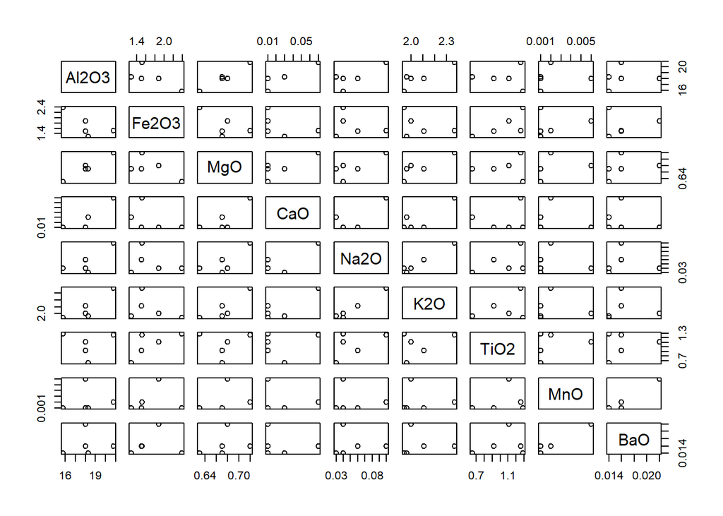

```r
pairs(pot_is[-c(1:3)])
```

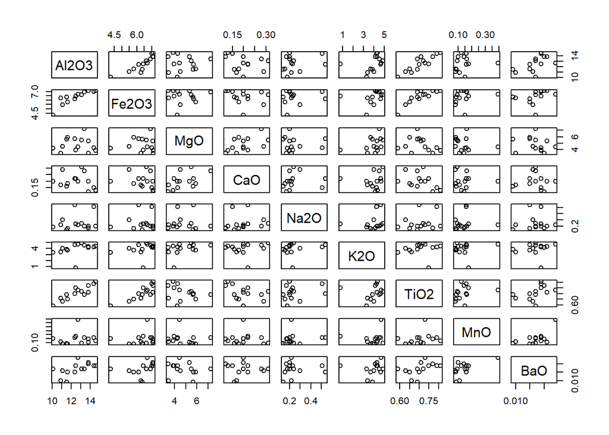

```r
pairs(pot_llan[-c(1:3)])
```

Though sample sizes vary, with Caldicot only having two observations, the general patterns of variance among groups look roughly the same.

3. Independence: The observations are independently sampled.

This assumption is satisfied if the pottery in the dataset are random samples of the pottery collected from each site. One way this could be violated is if samples were collected in groups within each site.

4. Normality: The data are multivariate normally distributed.

```r
library('Hmisc')
```

## format.pval, units

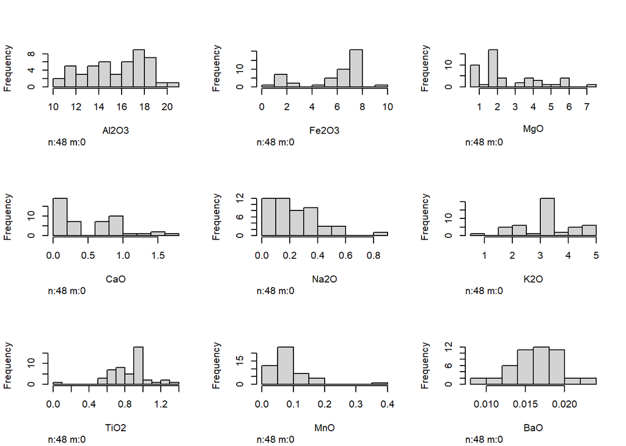

```r
hist.data.frame(RBPottery[-c(1:3)], nclass = 10)
```

We can see that some chemicals are normally distributed, while some are skewed or clustered. Per the Central Limit Theorem, sample mean vectors are approximately multivariate normally distributed, even if individual observations are not. We have $n=48$ samples, greater than the rule of thumb of 30 for the CLT to apply. However, as mentioned previously, some locations have a very small number of samples, like Caldicot. As such, we simply presume this assumption to hold for the purposes of this analysis and proceed.

### Analysis

We may partition the total sum of squares and cross products as follows:

$\begin{align*}{\mathbf T} & = \sum_{k=1}^g \sum_{i=1}^{n_k} { \left(\underline{x}_i^{(k)} - \overline{\underline{x}}\right) } { \left( \underline{x}_i^{(k)} - \overline{\underline{x}} \right) }^{\prime} \\& = \sum_{k=1}^g \sum_{i=1}^{n_k} { \left\{ \left(\underline{x}_i^{(k)} - \overline{\underline{x}}^{(k)} \right) + \left(\overline{\underline{x}}^{(k)} -\overline{\underline{x}} \right) \right\} } { \left\{ \left( \underline{x}_i^{(k)} - \overline{\underline{x}}^{(k)} \right) + \left(\overline{\underline{x}}^{(k)} -\overline{\underline{x}} \right) \right\} }^{\prime} \\ & = \sum_{k=1}^g \sum_{i=1}^{n_k} { \left(\underline{x}_i^{(k)} - \overline{\underline{x}}^{(k)} \right) } { \left( \underline{x}_i^{(k)} -\overline{\underline{x}}^{(k)} \right) }^{\prime} + \sum_{k=1}^g n_k { \left(\overline{\underline{x}}^{(k)} -\overline{\underline{x}} \right) } { \left( \overline{\underline{x}}^{(k)} -\overline{\underline{x}} \right) }^{\prime}.\end{align*}$

The first term $E$ is the Error Sum of Squares and Cross Products.

The second term $H$ is the Hypothesis Sum of Squares and Cross Products.

```r
pot <- NULL
pot <- rbind(pot,pot_llan)
pot <- rbind(pot,pot_cald)
pot <- rbind(pot,pot_is)
pot <- rbind(pot,pot_ar)
pot <- rbind(pot,pot_gl)

# Group: kiln 1
x1 <- pot[pot$Kiln==1,-c(1:3)]
m1 <- colMeans(x1)
n1 <- dim(x1)[1]

# Group: kiln 2
x2 <- pot[pot$Kiln==2,-c(1:3)]
m2 <- colMeans(x2)
n2 <- dim(x2)[1]
# Group: kiln 3
x3 <- pot[pot$Kiln==3,-c(1:3)]
m3 <- colMeans(x3)
n3 <- dim(x3)[1]
# Group: kiln 4
x4 <- pot[pot$Kiln==4,-c(1:3)]
m4 <- colMeans(x4)
n4 <- dim(x4)[1]
# Group: kiln 5
x5 <- pot[pot$Kiln==5,-c(1:3)]
m5 <- colMeans(x5)
n5 <- dim(x5)[1]
# Grand Mean
mg <- (m1*n1 + m2*n2 + m3*n3 + m4*n4 + m5*n5)/(n1+n2+n3+n4+n5)
```

Error Sum of Squares and Cross Products Matrix can be calculated as follows:

${\mathbf E} = \sum_{k=1}^g \sum_{i=1}^{n_k} { \left( \underline{x}_i^{(k)} - \overline{\underline{x}}^{(k)} \right) } { \left( \underline{x}_i^{(k)} -\overline{\underline{x}}^{(k)} \right) }^{\prime}.$

```r
ESS <- cov(x1)*(n1-1) + cov(x2)*(n2-1) + cov(x3)*(n3-1) + cov(x4)*(n4-1) + cov(x5)*(n5-1)
ESS
```

```
##             Al2O3       Fe2O3          MgO          CaO         Na2O
## Al2O3 96.20132468 21.11225325  5.506287013 -2.096574026  0.569593506
## Fe2O3 21.11225325 19.88942753  2.157729870 -0.685039740  0.918994935
## MgO    5.50628701  2.15772987 16.303520519  0.274558961  0.090970260
## CaO   -2.09657403 -0.68503974  0.274558961  1.760672078 -0.025830519
## Na2O   0.56959351  0.91899494  0.090970260 -0.025830519  0.735820130
## K2O   10.55401948  4.50978519  5.888079221  0.248701558  0.560279610
## TiO2   0.96768701  1.99152987  0.041040519 -0.120881039  0.062710260
## MnO    0.37119545  0.26490145 -0.131911818  0.009635636  0.059562091
## BaO    0.07495727  0.02567727 -0.007025091  0.004785182  0.004963455
##               K2O         TiO2          MnO           BaO
## Al2O3 10.55401948  0.967687013  0.371195455  0.0749572727
## Fe2O3  4.50978519  1.991529870  0.264901455  0.0256772727
## MgO    5.88807922  0.041040519 -0.131911818 -0.0070250909
## CaO    0.24870156 -0.120881039  0.009635636  0.0047851818
## Na2O   0.56027961  0.062710260  0.059562091  0.0049634545
## K2O   14.63247117  0.321679221  0.104890727  0.0100536364
## TiO2   0.32167922  1.368520519  0.015238182  0.0037669091
## MnO    0.10489073  0.015238182  0.089093964  0.0030718182
## BaO    0.01005364  0.003766909  0.003071818  0.0004249909
```

Hypothesis Sum of Squares and Cross Products Matrix can be calculated as follows:

${\mathbf H} = \sum_{k=1}^g n_k { \left(\overline{\underline{x}}^{(k)} -\overline{\underline{x}} \right) } { \left( \overline{\underline{x}}^{(k)} -\overline{\underline{x}} \right) }^{\prime}.$

```r
HSS <- n1*(m1 - mg) %*% t(m1 - mg) + n2*(m2 - mg) %*% t(m2 - mg) + n3*(m3 - mg) %*% t(m3 - mg) +
  n4*(m4 - mg) %*% t(m4 - mg) + n5*(m5 - mg) %*% t(m5 - mg)
HSS
```

```
##               Al2O3        Fe2O3           MgO          CaO         Na2O
##  [1,]  2.470585e+02 -62.83133658 -1.688936e+02 17.329699026  0.163614827
##  [2,] -6.283134e+01 238.85773913  7.165714e+01 32.920489740 12.025288398
##  [3,] -1.688936e+02  71.65713680  1.236503e+02 -8.167158961  1.759763074
##  [4,]  1.732970e+01  32.92048974 -8.167159e+00  7.750252922  1.953805519
##  [5,]  1.636148e-01  12.02528840  1.759763e+00  1.953805519  0.687171537
##  [6,] -6.954646e+01  50.83463981  5.080132e+01  0.919660942  1.596657890
##  [7,]  1.337898e+01  -6.37246320 -9.258374e+00  0.373681039 -0.128076926
##  [8,] -4.777120e+00   3.42203855  3.697632e+00 -0.002320636  0.128522909
##  [9,]  7.832311e-03   0.04981856  9.178424e-03  0.007261068  0.003436962
##                 K2O          TiO2           MnO          BaO
##  [1,] -69.546456981 13.3789796537 -4.7771204545 7.832311e-03
##  [2,]  50.834639805 -6.3724632035  3.4220385455 4.981856e-02
##  [3,]  50.801320779 -9.2583738528  3.6976318182 9.178424e-03
##  [4,]   0.919660942  0.3736810390 -0.0023206364 7.261068e-03
##  [5,]   1.596657890 -0.1280769264  0.1285229091 3.436962e-03
##  [6,]  25.307410081 -4.3025792208  1.6272767727 3.224489e-03
##  [7,]  -4.302579221  0.7823461472 -0.2784881818 2.364242e-04
##  [8,]   1.627276773 -0.2784881818  0.1193510364 6.309318e-04
##  [9,]   0.003224489  0.0002364242  0.0006309318 2.648826e-05
```

We reject the null hypothesis if the Hypothesis Sum of Squares and Cross Products matrix is “large” relative to the Error Sum of Squares and Cross Products matrix.

We will use four test statistics to determine this.

- Wilks’s Lambda (Ratio of Determinants)

$\Lambda = \frac{ \det {\mathbf E} }{ \det {\mathbf T}} = \frac{ \det {\mathbf E} }{ \det \left( {\mathbf E} + {\mathbf H} \right) }.$

- Pillai’s Trace (Trace of Ratio)

$V = \mbox{tr} \left[ {\mathbf H} { \left( {\mathbf H} + {\mathbf E} \right) }^{-1} \right],$

- Hotelling-Lawley Trace (Trace of Ratio)

$U = \mbox{tr} \left[ {\mathbf H} { {\mathbf E} }^{-1} \right],$

- Roy’s Maximum Root (Largest Eigenvalue of Ratio)

$R = \lambda_m \left[ {\mathbf H} { {\mathbf E} }^{-1} \right],$

```r
library(rootWishart)
N <- n1+n2+n3+n4+n5
g <- 5
p <- 9
output <- NULL

# Wilks Lambda
wilks <- det(ESS)/det(ESS + HSS)
wilk_f <- ((N - g) - (p - g + 2)/2)
wilk_xi <- 1
if((p^2 + (g-1)^2 - 5) > 0)
{
  wilk_xi <- sqrt((p^2*(g-1)^2 - 4)/(p^2 + (g-1)^2 - 5))
}
wilk_omega <- (p*(g-1)-2 )/2
wilks_stat <- (wilk_f*wilk_xi - wilk_omega)*
  (1 - wilks^(1/wilk_xi))/(p*(g-1)*wilks^(1/wilk_xi))
output <- rbind(output,c(wilks,wilks_stat,
  1 - pf(wilks_stat,df1 = p*(g-1), df2 = (wilk_f*wilk_xi - wilk_omega))))

# Pillai's Trace
pillai <- sum(diag(HSS %*% solve(ESS + HSS)))
pillai_s <- min(p,g-1)
pillai_m <- (abs(p-g+1)-1)/2
pillai_r <- (N-g-p-1)/2
pillai_stat <- (2*pillai_r + pillai_s + 1)*pillai/
  ((2*pillai_m + pillai_s + 1)*(pillai_s - pillai))
output <- rbind(output,c(pillai,pillai_stat,
  1 - pf(pillai_stat,df1 = pillai_s*(2*pillai_m + pillai_s + 1),
       df2 = pillai_s*(2*pillai_r + pillai_s + 1))))

# Hotelling-Lawley
hotel <- sum(diag(HSS %*% solve(ESS)))
hotel_b <- (N-p-2)*(N-g-1)/((N-g-p-3)*(N-g-p))
hotel_df1 <- p*(g-1)
hotel_df2 <- 4 + (hotel_df1 + 2)/(hotel_b - 1)
hotel_c <- hotel_df1*(hotel_df2 - 2)/(hotel_df2*(N-g-p-1))
hotel_stat <- hotel/hotel_c
output <- rbind(output,c(hotel,hotel_stat,
  1 - pf(hotel_stat,df1 = hotel_df1,df2 = hotel_df2)))

# Roy
roy <- max(Re(eigen(HSS %*% solve(ESS))$values))
roy_stat <- roy/(1+roy)
output <- rbind(output,c(roy,roy_stat,
  1 - doubleWishart(roy_stat,p=p,m=N-g,n=g-1)))
```

```
## Using multiprecision
```

```r
colnames(output) <- c("Statistic","Test Statistic","P-value")
rownames(output) <- c("Wilks","Pillai","Hotelling-Lawley","Roy")
output
```

```
##                     Statistic Test Statistic      P-value
## Wilks             0.001388136     17.6757748 0.000000e+00
## Pillai            2.226843233      5.3025357 1.391109e-13
## Hotelling-Lawley 44.728161807     41.9995682 0.000000e+00
## Roy              28.628211091      0.9662484 2.220446e-16
```

We can see all of our p-values are extremely small (some have been rounded to zero). All p-values are lower than our significance level $\alpha = 0.05$. There is a signficant difference among at least two group means for the 9 variables.

## Conclusion

We explored the pottery dataset and used MANOVA to see whether different locations had significantly different average values for 9 chemicals. We inspected the dataset and found that it generally satisfied the four assumptions required to perform MANOVA. We calculated the error sum of squares and hypothesis sum of squares and then looked at four test statistics which all had p-values less than our significance level, meaning not all groups had the same group means and at least two differed. We consequently determine that there is a significant difference among group means in these chemicals.